# Texas Political Demographics

Conor McMahon

9/3/2021

# 2020 Presidential Election

In the 2020 presidential election, Texas voted 52.1% for Trump and 46.5% for Biden. The vote breakdown was 5,890,347 and 5,259,126. For every Biden voter, there were 1.12 Trump voters.

The same year, in California Biden received 63.5% of the vote (11,110,250) and Trump 34.3% (6,006,429). In New York, it was 60.9% (5,244,886) for Biden and 37.7% (3,251,997) for Trump.

So, in 2020, more people voted for Trump in California than in Texas. Meanwhile, more people voted for Biden in Texas than in New York State.

In fact, the ONLY states in the United States where Joe Biden received more votes in 2020 than in Texas were California and Florida. Trump won Florida, too.

These data are from CNN: [$^{[1]}$](https://www.cnn.com/election/2020/results/president)

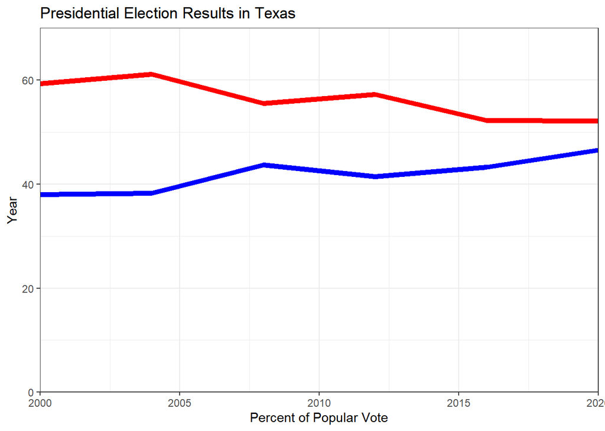

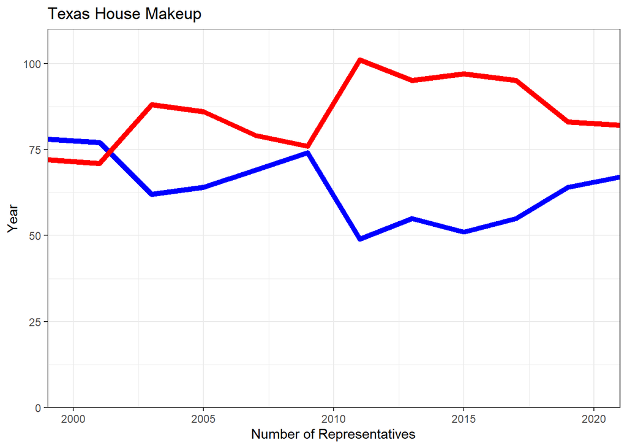

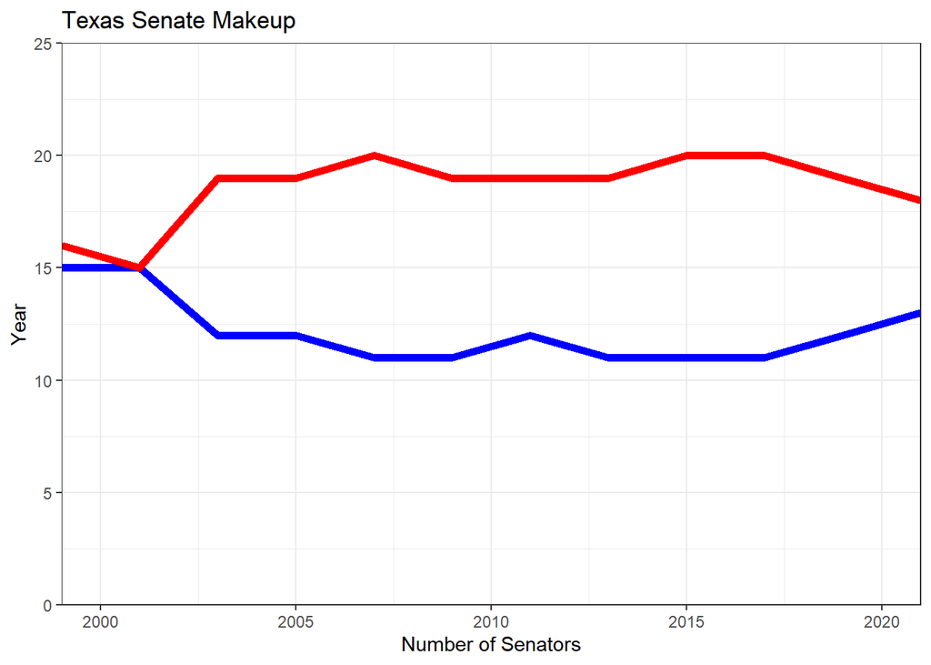

# Democrats in Texas

Again, in 2020, 46.5% of voters broke for Biden. Meanwhile, Pew[$^{[2]}$](https://www.pewforum.org/religious-landscape-study/state/texas/party-affiliation/) surveys suggest that about 40% of Texans self-identify as Democrats, or Democrat-leaning. According to the same survey, 39% identify as Republicans or Republican-leaning, and 21% have ‘no lean’.

Taking 40% of the population of Texas, which is 28,995,881[$^{[3]}$], we have about 11,598,352.

According to Pew[$^{4}$](https://www.pewforum.org/religious-landscape-study/compare/party-affiliation/by/state/), here is a table showing the political breakdown in those states:

| State | Population | Democratic (%) | Democrats |
| --- | --- | --- | --- |
| California | 39512223 | 49 | 19400000 |
| Texas | 28995881 | 40 | 11600000 |
| Florida | 21477737 | 44 | 9450000 |
| New York | 19453561 | 53 | 10300000 |
| Pennsylvania | 12801989 | 46 | 5890000 |
| Illinois | 12671821 | 48 | 6080000 |
| Ohio | 11689100 | 40 | 4680000 |
| Georgia | 10617423 | 41 | 4350000 |

So, again. The ONLY state with more Democrats in it than Texas, in the entire country, is California.

# Views on Abortion

According again to the Pew Research Center[$^{[5]}$](https://www.pewforum.org/religious-landscape-study/compare/views-about-abortion/by/state/), about 45% of Texans say that abortion should “be legal in most/all circumstances”, while about about 50% say it should “be illegal in most/all circumstances.” Similar numbers are reported for other states, too - the largest spread is in Massachusetts (74% legal, 22% illegal) and West Virginia (\35% legal, 58% illegal).

| State | Population | Demogcrat (%) | Democrats | Pro-Legality (%) | Pro-Legality | Pro-Illegality (%) | Pro-Illegality |
| --- | --- | --- | --- | --- | --- | --- | --- |
| California | 39,512,223 | 49 | 19,400,000 | 57 | 22,500,000 | 38 | 15,000,000 |
| Texas | 28,995,881 | 40 | 11,600,000 | 45 | 13,000,000 | 50 | 14,500,000 |
| Florida | 21,477,737 | 44 | 9,450,000 | 56 | 12,000,000 | 39 | 8,380,000 |
| New York | 19,453,561 | 53 | 10,300,000 | 64 | 12,500,000 | 32 | 6,230,000 |
| Pennsylvania | 12,801,989 | 46 | 5,890,000 | 52 | 6,660,000 | 44 | 5,630,000 |
| Illinois | 12,671,821 | 48 | 6,080,000 | 56 | 7,100,000 | 41 | 5,200,000 |
| Ohio | 11,689,100 | 40 | 4,680,000 | 48 | 5,610,000 | 47 | 5,490,000 |
| Georgia | 10,617,423 | 41 | 4,350,000 | 48 | 5,100,000 | 49 | 5,200,000 |